# April Garrett’s Bio381 Homepage

## Computational Biology: Spring 2017

## About Me:

#### I am an aspiring marine biologist and second year PhD student in Dr. Melissa Pespeni’s lab at the University of Vermont. [Link to my UVM webpage.](http://www.uvm.edu/~biology/?Page=students/makukhov.php&SM=facultysubmenu.html)

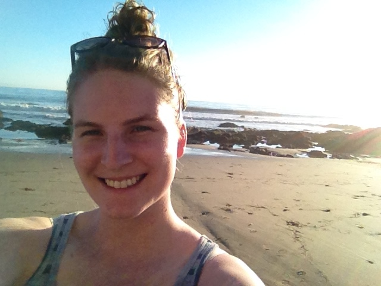

##### Me in California during Fall 2016 field collections of the purple sea urchin, *Strongylocentrotus purpuratus*.

Link to my current CV.

## R Presentation on SNPRelate Package: 04/19/2017

- Download Data File Here
- Code for Presentation Here

## Homework:

- Assignment 1: Links and fun fact emailed to Nick
- Assignment 2
- Assignment 3: Beamer
  - Powerpoint
  - Beamer Slides RMarkdown File
  - Beamer PDF Slides
- Assignment 4: Data upload & Regular Expressions
  - Uploading Data in R
  - Regular Expressions
- Assignment 5: Working in R
  - Assignment
  - Notes
- Assignment 6
- Assignment 7: Finish function summaries & provide text files to Lauren
  - ‘list’ function
  - ‘pmax’ function
  - ‘var’ function
  - ‘xor’ function
  - ‘!=’ function
  - ‘abs’ function
  - ‘^’ function
  - ‘save’ function
  - ‘log10’ function
- Assignment 8: Models and plots in R
  - Assignment
  - Notes
- Assignment 9: Running models on own data & random dataset
  - Assignment
- Assignment 10: For loops
  - Assignment
- Assignment 11: Spatial analysis in R
  - Assignment/Notes

## Notes:

- Intro to GitHub, RMarkdown, and Making Homepage
- Tools for Thinking Hypotheses Through on Paper (handwritten in notebook)
- Plain-text Files & RMarkdown & LaTeX
- R Markdown Demo Part 1
- R Markdown Demo Part 2
- Importing Data in R
- Data Structures in R Part 1
- Data Structures in R Part 2
- Subsetting in R
- Probability Distributions
- Working with Functions in R
- MyFunctions
- Sourcing Script
- Control Structures
- For Loops
- Function Template
- Randomization Tests
- Markov Models Part 1
- Markov Models Part 2
- Apply Functions
- Graphics Part 1
- Graphics Part 2
- Histograms in R